# Reproducible Research - Peer Project 1

## by John Baker

Project Summary

It is now possible to collect a large amount of data about personal movement using activity monitoring devices such as a Fitbit, Nike Fuelband, or Jawbone Up. These type of devices are part of the “quantified self” movement – a group of enthusiasts who take measurements about themselves regularly to improve their health, to find patterns in their behavior, or because they are tech geeks. But these data remain under-utilized both because the raw data are hard to obtain and there is a lack of statistical methods and software for processing and interpreting the data.

This assignment makes use of data from a personal activity monitoring device. This device collects data at 5 minute intervals through out the day. The data consists of two months of data from an anonymous individual collected during the months of October and November, 2012 and include the number of steps taken in 5 minute intervals each day.

See below for all code and answers to questions on Project 1 summary.

Load packages (dplyr, ggplot2, scales)

```r
library(dplyr)
```

```r
library(ggplot2)
library(scales)
```

Load in the data (csv file) and process into a format suitable for analysis

```r
steps <- read.csv("~/Desktop/Coursera/activity.csv", header = TRUE)
```

Step 1 - Convert date to Date

```r
steps$date <- as.Date(steps$date)
```

Step 2 - Convert time format to HH:MM

```r
steps$interval <- format(strptime(formatC(steps$interval, width = 4, format = "d",
                                          flag = "0"), format = "%H%M"), format ="%H:%M")
```

What is the mean total number of steps taken per day?

Step 1 - Calculate total steps per day

```r
dailySteps <- steps %>%
        group_by(date) %>%
        summarise(total=sum(steps))
```

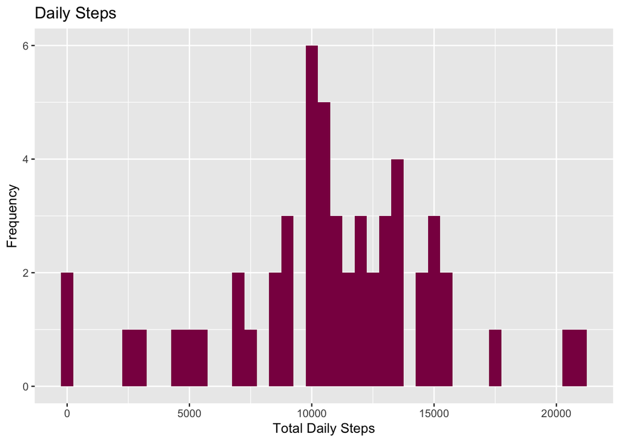

```r
ggplot(dailySteps, aes(total)) +
        geom_histogram(binwidth = 500, fill="deeppink4") +
        labs(x="Total Daily Steps", y="Frequency", title = "Daily Steps")
```

Calculate and report the mean and median of the total number of steps per day

```r
mean(dailySteps$total, na.rm = TRUE)
```

```
## [1] 10766.19
```

[1] 10766.19

```r
median(dailySteps$total, na.rm = TRUE)
```

```
## [1] 10765
```

[1] 10765

What is the avg. daily activity pattern?

Step 1 - Calculate the mean number of steps taken for every five minute interval and average that across days

```r
intSteps <- steps %>%
        group_by(interval) %>%
        summarize(mean=mean(steps, na.rm = TRUE))
```

Step 2 - Create a plot showing time series and the average daily pattern of activity

[figure not shown]

```r
ggplot(intSteps, aes(as.POSIXct(interval, format="%H:%M"), mean)) +
        geom_line(col="deeppink4") +
        scale_x_datetime(labels = date_format("%H:%M"),
                         date_breaks = "4 hours") +
        labs(x="Five Minute Interval", y="Number of Steps", title="Average steps by time of day")
```

Step 3 - Calculate which 5-minute interval, on avg. across all days in the dataset, contains the maximum number of steps…

```r
max(intSteps$mean)
```

```
## [1] 206.1698
```

[1] 206.1698

…which occurs in this time interval:

```r
intSteps[which.max(intSteps$mean), ]
```

```
## # A tibble: 1 x 2
##   interval  mean
##   <chr>    <dbl>
## 1 08:35     206.
```

Imput all missing values in dataset

Step 1 - Calculate and show total number of missing values in dataset

```r
sum(!complete.cases(steps))
```

```
## [1] 2304
```

[1] 2304

Step 2 - Create a new dataset that equals the original dataset but w/ missing data…

```r
imputeSteps <- steps %>%
        group_by(interval) %>%
        mutate(steps=ifelse(is.na(steps), mean(steps, na.rm = TRUE), steps))
```

Step 3 - Create a new histogram of the total number of steps taken each day w/ missing values…

```r
imputedDailySteps <- imputeSteps %>%
        group_by(date) %>%
        summarize(total=sum(steps))
```

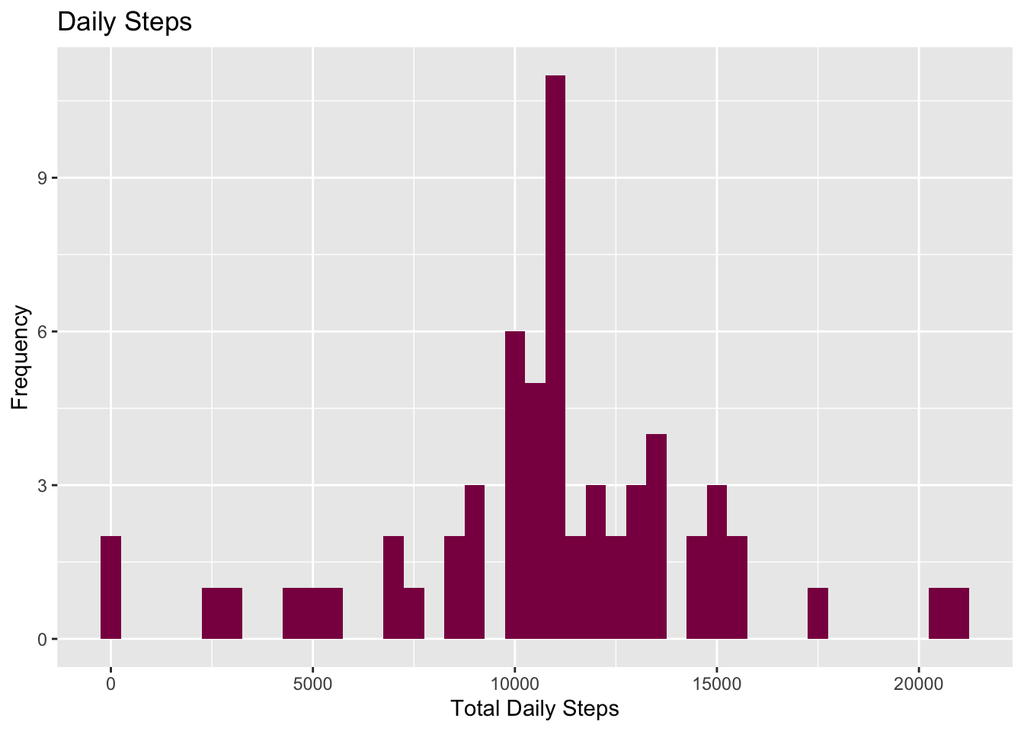

```r
ggplot(imputedDailySteps, aes(total)) +
        geom_histogram(binwidth = 500, fill="deeppink4") +
        labs(x="Total Daily Steps", y="Frequency", title = "Daily Steps")
```

Calculate and report the mean and median of the total number of steps per day

```r
mean(imputedDailySteps$total, na.rm = TRUE)
```

```
## [1] 10766.19
```

[1] 10766.19

```r
median(imputedDailySteps$total, na.rm = TRUE)
```

```
## [1] 10766.19
```

[1] 10766.19

Are there differences in activity patterns when comparing weekdays to weekends?

Step 1 - Create new factor variable in dataset with weekday and weekend levels

```r
wSteps <- imputeSteps %>%
        mutate(wkday=ifelse(weekdays(date) %in% c("Saturdar", "Sunday"), "Weekend", "Weekday"))
```

Turn into a factor

```r
wSteps <- wSteps %>%
        mutate(wkday=as.factor(wkday))
```

Step 2 - Group according to interval and weekday (wkday/factor) and again calculate the mean # steps

```r
wIntSteps <- wSteps %>%
        group_by(interval,wkday) %>%
        summarize(mean=mean(steps, na.rm = TRUE))
```

Create time series plot with faceting on the new weekday (wkday) factor

[figure not shown]

```r
ggplot(wIntSteps, aes(as.POSIXct(interval, format = "%H:%M"), mean, col=wkday)) +
        geom_line(show.legend = F) +
        facet_grid(rows = wIntSteps$wkday) +
        scale_x_datetime(labels = date_format("%H:%M"),
                         date_breaks = "4 hours") +
        labs(x="Five Minute Interval", y="Number of Steps", title = "Average steps by time of day")
```